# Who’s Getting Vaccinated for Measles in U.S. Schools?

Abby Isaacson

3/22/2021

# Introduction

> *Could student vaccination rates for Measles, Mumps and Rubella (MMR) predict COVID-19 vaccination rates among schools, once a child vaccine becomes available?*

Measles is disease that was essentially suppressed for 25 years in the U.S. through vaccination, but **showed a significant resurgence** in 2019.

This report examines data from 32 states and more than 46,000 schools that reported student measles, mumps and rubella (MMR) vaccination data for kindergarten students between 2017 and 2019. By looking at how many schools have reached state vaccine recommendations for MMR, public health organizations may better target future vaccination outreach efforts for COVID-19 to prevent disease outbreaks among students in the future.

# About Reporting Schools

46,243 schools from 32 states reported overall and/or MMR vaccination rates for their kindergarten classes in the 2017-2018 or 2018-2019 school years. California had the most reporting schools (8,052), and the smallest reporting came from Rhode Island (230 schools).

The majority of reporting schools represented were public, followed by private and kindergarten only, and then much smaller representation of charter, non-private and [BOCES](https://www.boces.org) (a New York model called Boards of Cooperative Education Services).

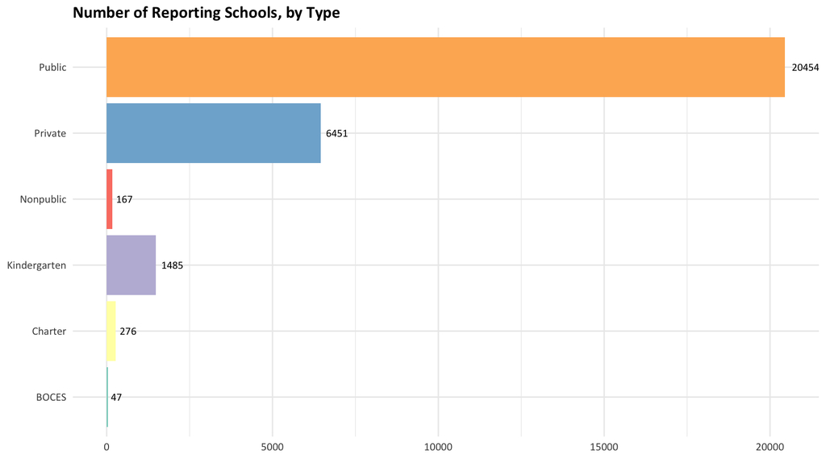

The majority of reporting schools’ enrollment numbers were smaller than 250 students for elementary/kindergarten classes, although a few schools reported as many as 6,000 students (likely included all school enrollment, not just kindergarten).

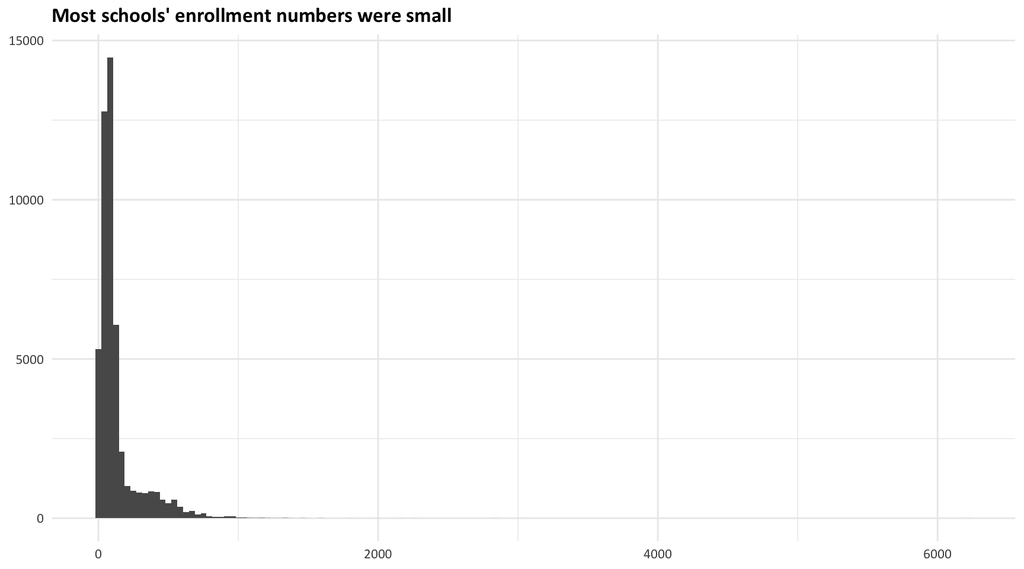

# Vaccination Rates Among Reporting Schools

Most individual schools reported MMR vaccination rates above 90%, while overall vaccination rates were slightly lower and more unevenly distributed:

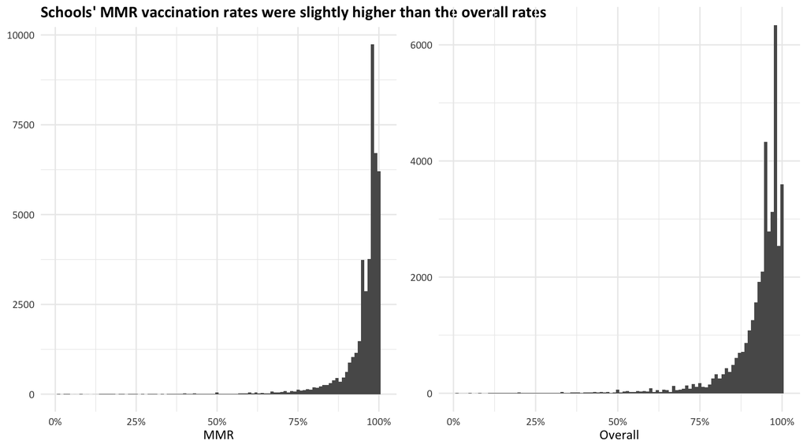

Among the 21 states that reported MMR rates, **eight states (38%) had average MMR vaccination rates above 95%**. Illinois and Massachusetts reported the two highest rates (97.1%, 96.9%). Arkansas reported the lowest mean vaccination rate (80.5%), followed by Washington (89.3%).

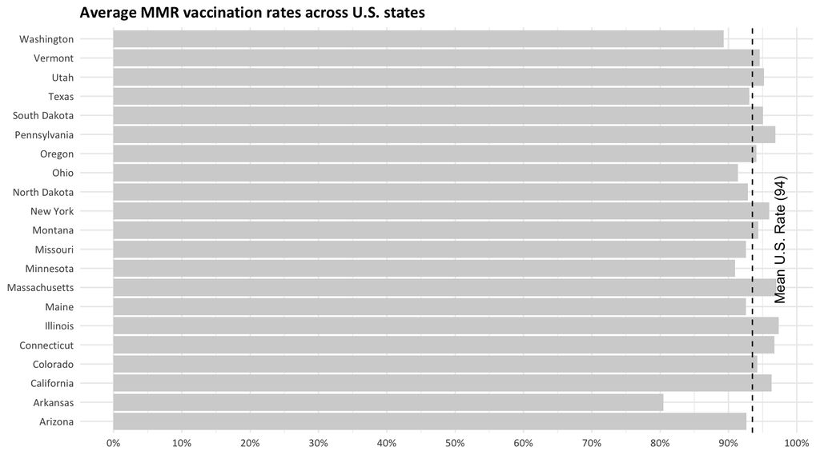

Among the 17 states that reported overall vaccination rates, North Carolina (96.83%) and Iowa (95.8%) reported the highest rates. Idaho was lowest at 82.4%, followed by four other states with rates below 90%: Washington, Wisconsin, Colorado and Ohio.

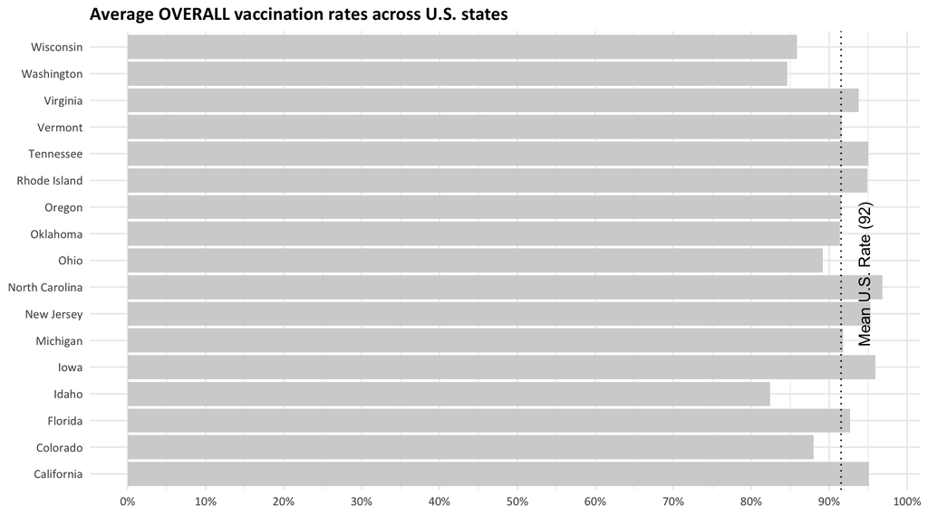

Mean MMR vaccination rates varied somewhat by *school type*. BOCES schools in New York reported the highest mean MMR rates, followed closely by public schools (both above 95%). Charter schools averaged the lowest MMR rate (just below 90%).

Not all school types reported overall vaccination rates, which were lower than MMR rates (between 88-93%).

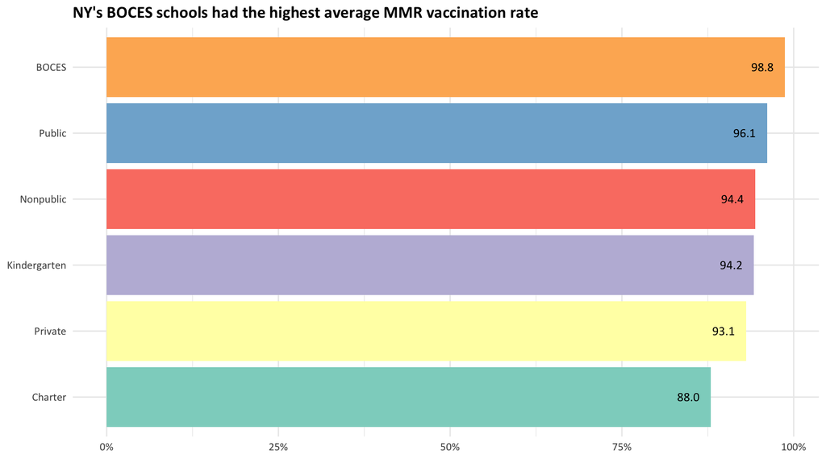

# Personal, Medical and Religious Exemptions

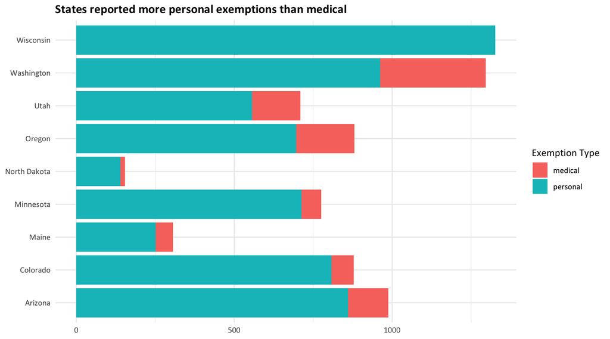

The majority of states had less than 5% of their schools reporting small numbers student personal or medical exemptions.

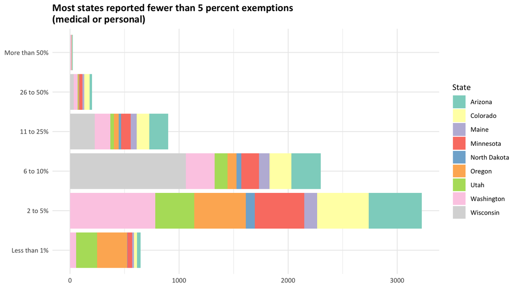

*Wisconsin* reported a high number of personal exemptions compared to other states, which may have had an impact on its relatively low overall vaccination rate average. However, it did not report MMR rates, which limits one’s ability to deduce the impact of exemptions on MMR vaccination rate in that state.

*Washington’s* higher exemption numbers may account for its lower average vaccination rates. Washington reported the largest number of medical exemptions of any state.

# Individual State Analyses: Low MMR Vaccination Rates

Thirteen states (or 61%) have mean MMR rates below the recommended 95%. *Arkansas* and *Washington* reported the two lowest MMR vaccination rates (both below 90%). Only two Arkansas schools (0.4%) reported MMR vaccination rates above 95%. Arkansas did not provide any exemption data, so it is difficult to determine how exemptions may have played a role in its low mean MMR rate. Washington reported a high number of exemptions compared to other states and the second lowest mean MMR vaccination rate.

Again, while *Wisconsin* reported the highest number of exemptions, it did not report MMR vaccination rates, only overall vaccination rates, which were well below the U.S. average. The relationship between exemptions and low vaccination rates deserves further investigation when more complete data is available.

| State | Mean MMR Rate |
| --- | --- |
| Arkansas | 80.49296 |
| Washington | 89.32604 |
| Minnesota | 90.94104 |
| Ohio | 91.40988 |
| Maine | 92.54730 |
| Missouri | 92.56512 |
| Arizona | 92.63085 |
| North Dakota | 92.83731 |
| Texas | 93.08031 |
| Oregon | 94.08115 |
| Colorado | 94.22300 |
| Montana | 94.39172 |
| Vermont | 94.58332 |

A map of Washington state schools whose mean MMR rates were below 95% shows clusters of schools across counties and surrounding urban areas. Sixty-two percent of Washington schools had rates below the recommended 95% (black points on the map). Schools with sufficient rates appear in light blue:

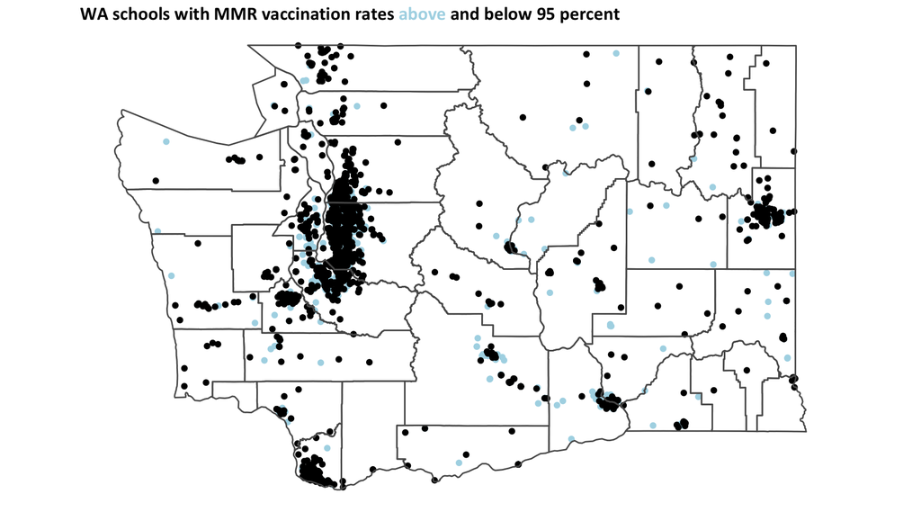

# Conclusions

Based on this report, which reveals where MMR vaccination rates are lowest across the U.S., public health workers may gain insights for targeting future vaccination efforts for other diseases requiring high herd immunity. Although COVID-19 may need a lower community vaccination rate than Measles, Mumps and Rubella to reach herd immunity, increasing efforts in Washington, Arkansas, Wisconsin, and among charter schools could be a place to start. With regard to low overall vaccination rates and not just MMR rates, the data shows that Idaho, Colorado and Ohio are additional states to garner our attention and perhaps enhance outreach efforts.